# Primer Proyecto Integrador

# Índice

1. Limpieza de datos
   - Carga de datos
   - Duplicacios y valores ausentes
   - Tipo de datos
   - Creacion de columnas
2. Análisis de datos
   - Juegos por año
   - Ventas
   - Rentabilidad
3. Perfil de usuario para cada region
   - Plataformas principales
   - Generos principales
   - Clasificacion ESRB
4. Prueba de hipotesis
   - Calificaciones promedio de los usuarios para las plataformas Xbox One y PC
   - calificaciones promedio de los usuarios para los géneros de Acción y Deportes

5.Conclusion general

### Limpieza de datos

```python
import pandas as pd
import numpy as np
import scipy.stats as sts
import seaborn as sns
import matplotlib.pyplot as plt
```

```python
games = pd.read_csv("/datasets/games.csv")
games.info()
```

```
<class 'pandas.core.frame.DataFrame'>
RangeIndex: 16715 entries, 0 to 16714
Data columns (total 11 columns):
 #   Column           Non-Null Count  Dtype
---  ------           --------------  -----
 0   Name             16713 non-null  object
 1   Platform         16715 non-null  object
 2   Year_of_Release  16446 non-null  float64
 3   Genre            16713 non-null  object
 4   NA_sales         16715 non-null  float64
 5   EU_sales         16715 non-null  float64
 6   JP_sales         16715 non-null  float64
 7   Other_sales      16715 non-null  float64
 8   Critic_Score     8137 non-null   float64
 9   User_Score       10014 non-null  object
 10  Rating           9949 non-null   object
dtypes: float64(6), object(5)
memory usage: 1.4+ MB
```

```python
games.columns = games.columns.str.lower()
```

```python
games['year_of_release'].isna().sum()
```

```
269
```

```python
games= games.dropna(subset=['year_of_release'])

games['year_of_release'] = games['year_of_release'].astype("int")

print(games.head())
```

```
                       name platform  year_of_release         genre  na_sales  \
0                Wii Sports      Wii             2006        Sports     41.36
1         Super Mario Bros.      NES             1985      Platform     29.08
2            Mario Kart Wii      Wii             2008        Racing     15.68
3         Wii Sports Resort      Wii             2009        Sports     15.61
4  Pokemon Red/Pokemon Blue       GB             1996  Role-Playing     11.27

   eu_sales  jp_sales  other_sales  critic_score user_score rating
0     28.96      3.77         8.45          76.0          8      E
1      3.58      6.81         0.77           NaN        NaN    NaN
2     12.76      3.79         3.29          82.0        8.3      E
3     10.93      3.28         2.95          80.0          8      E
4      8.89     10.22         1.00           NaN        NaN    NaN
```

```python
games['year_of_release'] = pd.to_datetime(games['year_of_release'], format='%Y').dt.year
print(games['year_of_release'].dtypes)
```

```
int64
```

```python
games["critic_score"]=games["critic_score"].fillna(0)
games["critic_score"]=games["critic_score"].astype(int)

games["user_score"]=games["user_score"].fillna(0)
games["user_score"]=games["user_score"].replace("tbd", 0)
games["user_score"]=games["user_score"].astype(float)

games["rating"]=games["rating"].fillna(" ")

games ["genre"] = games["genre"].fillna(" ")
```

Se modificaron las columnas : "critic_score" y "user_score" tenian valores ausentes, mediante el metodo fillna, dichos valores fueron cambiados por cero, en la columna user_score en algunas celdas estaba la abreviatura TBD, que fue tambien reemplaza por ceros y esta columna paso de ser object a ser de tipo float.

igualmente la columna critic_score fue cambiada de float a int.

La columna yer_of_release. los valores ausentes fueron eliminados mediente dropna, ya que eran valores ausentes aleatorios y no hay un gran riesgo de perder informacion valiosa. y paso de ser float a int.

Por ultimo la columna "rating" los valores ausentes se dejaron en blanco.

```python
games ["total_sales"] = games["na_sales"] + games["jp_sales"] + games ["eu_sales"] + games["other_sales"]

print(games.head())
```

```
                       name platform  year_of_release         genre  na_sales  \
0                Wii Sports      Wii             2006        Sports     41.36
1         Super Mario Bros.      NES             1985      Platform     29.08
2            Mario Kart Wii      Wii             2008        Racing     15.68
3         Wii Sports Resort      Wii             2009        Sports     15.61
4  Pokemon Red/Pokemon Blue       GB             1996  Role-Playing     11.27

   eu_sales  jp_sales  other_sales  critic_score  user_score rating  \
0     28.96      3.77         8.45            76         8.0      E
1      3.58      6.81         0.77             0         0.0
2     12.76      3.79         3.29            82         8.3      E
3     10.93      3.28         2.95            80         8.0      E
4      8.89     10.22         1.00             0         0.0

   total_sales
0        82.54
1        40.24
2        35.52
3        32.77
4        31.38
```

### Analisis de datos

```python
juegos_por_ano = games['year_of_release'].value_counts().sort_index()

print(juegos_por_ano)
```

```
1980       9
1981      46
1982      36
1983      17
1984      14
1985      14
1986      21
1987      16
1988      15
1989      17
1990      16
1991      41
1992      43
1993      62
1994     121
```

[output cut: 23 more lines]

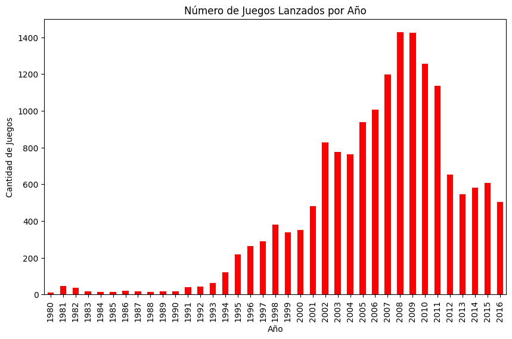

```python
color = "red"
juegos_por_ano.plot(kind='bar',color=color, figsize=(10, 6))
plt.title('Número de Juegos Lanzados por Año')
plt.xlabel('Año')
plt.ylabel('Cantidad de Juegos')
plt.show()
```

Es significativo el incremento en la cantidad de juegos lanzados por año, estamos hablando que entre el primer año de registo que es 1980 a 2008 (que es el año con mayor numero de lanzamiento) hay un incremento de mas del 15.000%, y tambien es significativo el descenso para el periodo de 2016.

```python
ventas_totales_plataforma = games.groupby('platform')['total_sales'].sum()


print("Ventas totales por plataforma:")
print(ventas_totales_plataforma)
```

```
Ventas totales por plataforma:
platform
2600      86.48
3DO        0.10
3DS      257.81
DC        15.95
DS       802.78
GB       254.43
GBA      312.88
GC       196.73
GEN       30.77
GG         0.04
N64      218.01
NES      251.05
NG         1.44
PC       255.76
PCFX       0.03
PS       727.58
PS2     1233.56
PS3      931.34
PS4      314.14
PSP      289.53
PSV       53.81
SAT       33.59
SCD        1.86
SNES     200.04
TG16       0.16
WS         1.42
Wii      891.18
WiiU      82.19
X360     961.24
XB       251.57
XOne     159.32
Name: total_sales, dtype: float64
```

```python
plataformas_top = ventas_totales_plataforma.sort_values(ascending=False).head(5).index.tolist()

plataformas_top_df = games[games['platform'].isin(plataformas_top)]

print(plataformas_top)
```

```
['PS2', 'X360', 'PS3', 'Wii', 'DS']
```

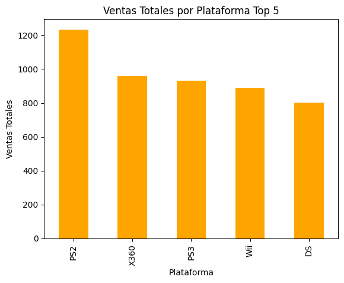

```python
df_top5 = games[games['platform'].isin(plataformas_top)]
ventas_por_plataforma = df_top5.groupby('platform')['total_sales'].sum().sort_values(ascending=False)

color = "orange"
ventas_por_plataforma.plot(kind='bar', color = color)
plt.title('Ventas Totales por Plataforma Top 5')
plt.xlabel('Plataforma')
plt.ylabel('Ventas Totales')
plt.show()
```

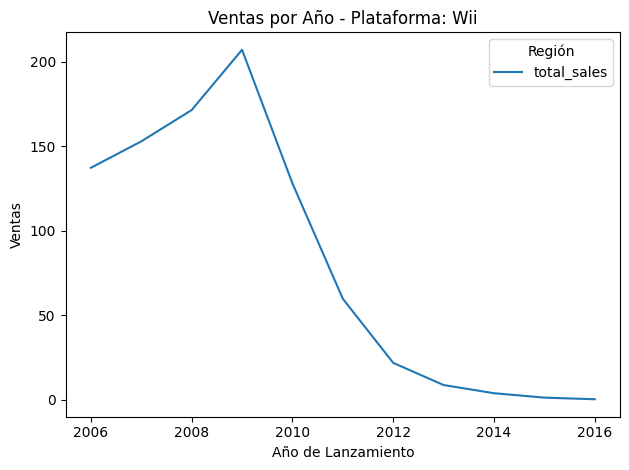

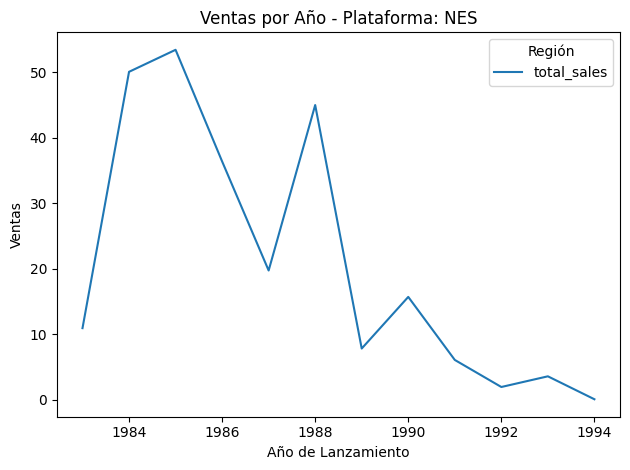

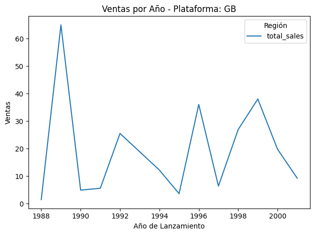

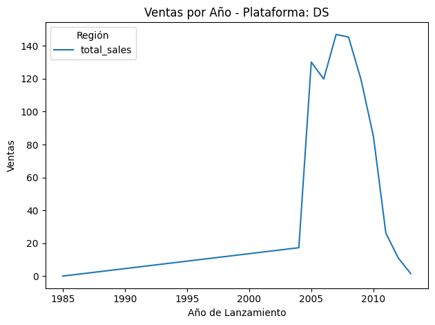

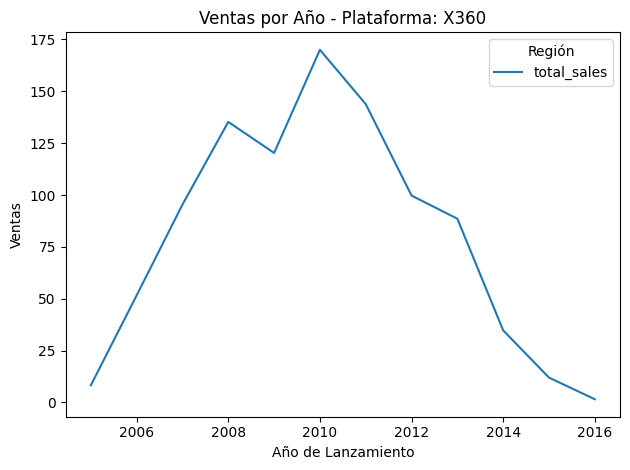

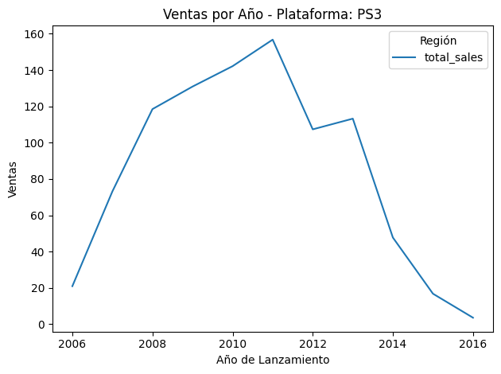

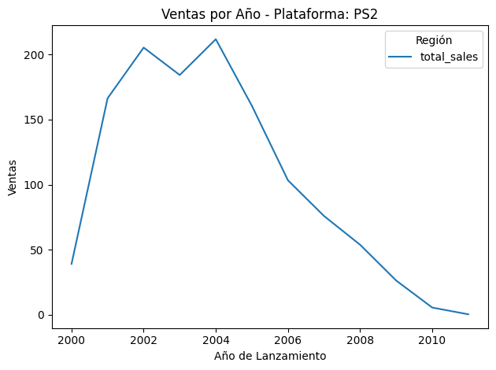

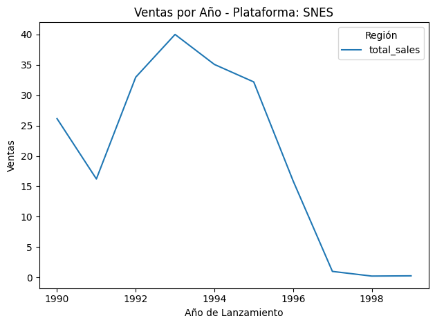

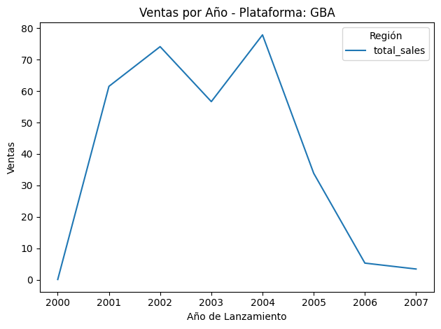

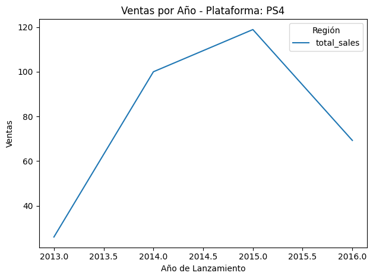

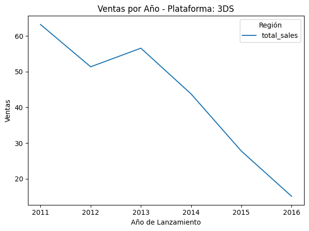

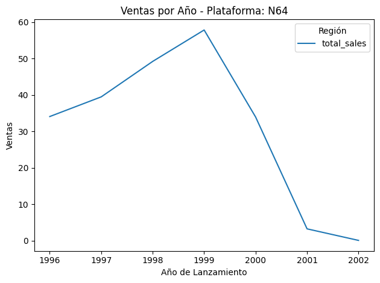

[19 more figures not shown]

```python
for plataforma in games['platform'].unique():
    plataforma_df = games[games['platform'] == plataforma]
    ventas_por_ano = plataforma_df.groupby('year_of_release')['total_sales'].sum()
    ventas_por_ano.plot(kind='line')
    plt.title(f'Ventas por Año - Plataforma: {plataforma}')  # Ajusta el tamaño de la fuente
    plt.xlabel('Año de Lanzamiento')
    plt.ylabel('Ventas')
    plt.legend(title='Región')
    plt.tight_layout()
    plt.show()
```

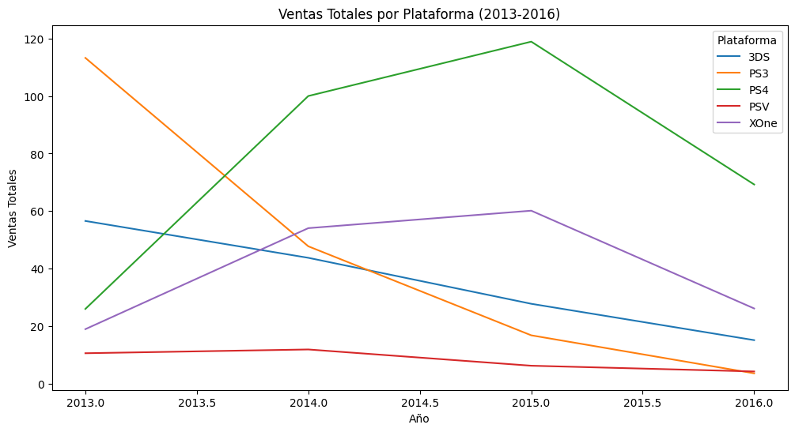

```python
games_filtro = games[(games['year_of_release'] >= 2013) & (games['year_of_release'] <= 2016)]

top_consolas = games_filtro['platform'].value_counts().head(5).index

games_filtro = games_filtro[games_filtro['platform'].isin(top_consolas)]

consolas_ventas = games_filtro.groupby(['platform', 'year_of_release'])['total_sales'].sum().reset_index()

plt.figure(figsize=(12, 6))
sns.lineplot(x='year_of_release', y='total_sales', hue='platform', data=consolas_ventas)
plt.title('Ventas Totales por Plataforma (2013-2016)')
plt.xlabel('Año')
plt.ylabel('Ventas Totales')
plt.legend(title='Plataforma')
plt.show()
```

Podemos observar un patron en las graficas, de picos altos y a su vez descensos bruscos, la causa de estos descensos pueden ocurrir por el estreno de nuevas consolas, por ejemplo las PS, PS2, PS4, claramente su descenso ocurre cuando sale a la venta una nueva consola. Entonces las consolas que fueron creadas antes del 2000 al haber nuevas graficas, con mejor tecnologia, nuevos juegos tienden a dejar de venderse.

```python
plataformas_rentables = games.groupby('platform').agg({'total_sales': 'sum', 'critic_score': 'mean'}).sort_values(by=['total_sales', 'critic_score'], ascending=False)
print(plataformas_rentables)
```

```
          total_sales  critic_score
platform
PS2           1233.56     41.189939
X360           961.24     49.841721
PS3            931.34     43.382083
Wii            891.18     27.727838
DS             802.78     21.272984
PS             727.58     11.790756
PS4            314.14     46.344388
GBA            312.88     35.689273
PSP            289.53     25.813915
3DS            257.81     21.773438
PC             255.76     55.457680
GB             254.43      0.000000
XB             251.57     61.466999
NES            251.05      0.000000
N64            218.01      0.000000
SNES           200.04      0.000000
GC             196.73     56.118081
XOne           159.32     50.170040
2600            86.48      0.000000
WiiU            82.19     43.306122
PSV             53.81     19.620047
SAT             33.59      0.000000
GEN             30.77      0.000000
DC              15.95     23.519231
SCD              1.86      0.000000
NG               1.44      0.000000
WS               1.42      0.000000
TG16             0.16      0.000000
3DO              0.10      0.000000
GG               0.04      0.000000
PCFX             0.03      0.000000
```

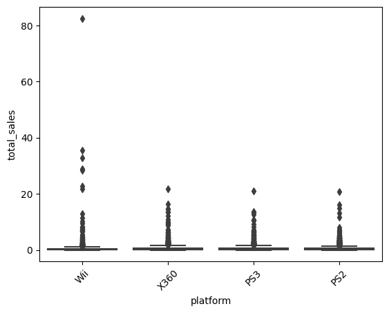

```python
filtro_consolas = games[games['platform'].isin(['PS2', 'X360', 'PS3', 'Wii'])]


sns.boxplot(
    x = "platform",
    y = "total_sales",
    data=filtro_consolas)


plt.xticks(rotation=45)
plt.show()
```

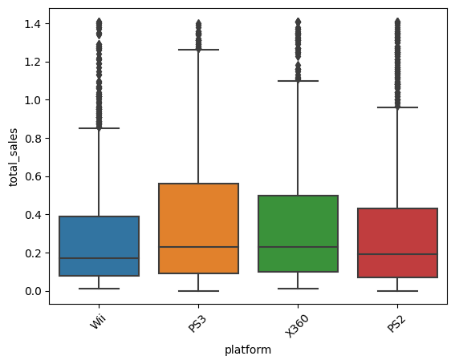

```python
Q1 = filtro_consolas['total_sales'].quantile(0.25)
Q3 = filtro_consolas['total_sales'].quantile(0.75)
IQR = Q3 - Q1

lower_bound = Q1 - 1.5 * IQR
upper_bound = Q3 + 1.5 * IQR

filtro_consolas_sin_atipicos = filtro_consolas[
    (filtro_consolas['total_sales'] >= lower_bound) &
    (filtro_consolas['total_sales'] <= upper_bound)]

sns.boxplot(
    x="platform",
    y="total_sales",
    data=filtro_consolas_sin_atipicos)

plt.xticks(rotation=45)
plt.show()
```

```python
promedio_puntuaciones = games.groupby("platform")["critic_score"].mean()
ventas = games.groupby ("platform")["total_sales"].sum()
df_concat = pd.concat([promedio_puntuaciones, ventas], axis="columns")

print(df_concat)
```

```
          critic_score  total_sales
platform
2600          0.000000        86.48
3DO           0.000000         0.10
3DS          21.773438       257.81
DC           23.519231        15.95
DS           21.272984       802.78
GB            0.000000       254.43
GBA          35.689273       312.88
GC           56.118081       196.73
GEN           0.000000        30.77
GG            0.000000         0.04
N64           0.000000       218.01
NES           0.000000       251.05
NG            0.000000         1.44
PC           55.457680       255.76
PCFX          0.000000         0.03
PS           11.790756       727.58
PS2          41.189939      1233.56
PS3          43.382083       931.34
PS4          46.344388       314.14
PSP          25.813915       289.53
PSV          19.620047        53.81
SAT           0.000000        33.59
SCD           0.000000         1.86
SNES          0.000000       200.04
TG16          0.000000         0.16
WS            0.000000         1.42
Wii          27.727838       891.18
WiiU         43.306122        82.19
X360         49.841721       961.24
XB           61.466999       251.57
XOne         50.170040       159.32
```

No hay una correlación directa evidente entre la puntuación media de los críticos y las ventas totales. Algunas plataformas con altas puntuaciones (como PC) tienen ventas moderadas, mientras que otras con puntuaciones bajas (como PS2) lideran en ventas

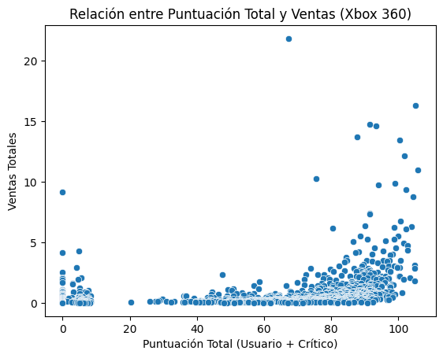

```
Correlación: 0.30797981145425
```

```python
x360 = games[games["platform"] == "X360"]
x360.loc[:, 'total_score'] = x360['user_score'] + x360['critic_score']

sns.scatterplot(x='total_score', y='total_sales', data=x360)
plt.title('Relación entre Puntuación Total y Ventas (Xbox 360)')
plt.xlabel('Puntuación Total (Usuario + Crítico)')
plt.ylabel('Ventas Totales')
plt.show()

correlacion = x360['total_score'].corr(x360['total_sales'])
print('Correlación:', correlacion)
```

Si bien existe una correlación positiva, no se puede afirmar que una puntuación alta garantice unas ventas altas.

```python
unique_names = games['name'].unique()
print(unique_names)
```

```
['Wii Sports' 'Super Mario Bros.' 'Mario Kart Wii' ...
 'Woody Woodpecker in Crazy Castle 5' 'LMA Manager 2007'
 'Haitaka no Psychedelica']
```

```python
ventas_por_juego = games.groupby(['name', 'platform'])['total_sales'].sum().reset_index()

ventas_pivot = ventas_por_juego.pivot_table(index='name', columns='platform', values='total_sales')
```

```python
distribucion_por_genero = games['genre'].value_counts().sort_values(ascending=False)

print(distribucion_por_genero)
```

```
Action          3307
Sports          2306
Misc            1721
Role-Playing    1481
Shooter         1296
Adventure       1293
Racing          1226
Platform         878
Simulation       857
Fighting         837
Strategy         673
Puzzle           569
                   2
Name: genre, dtype: int64
```

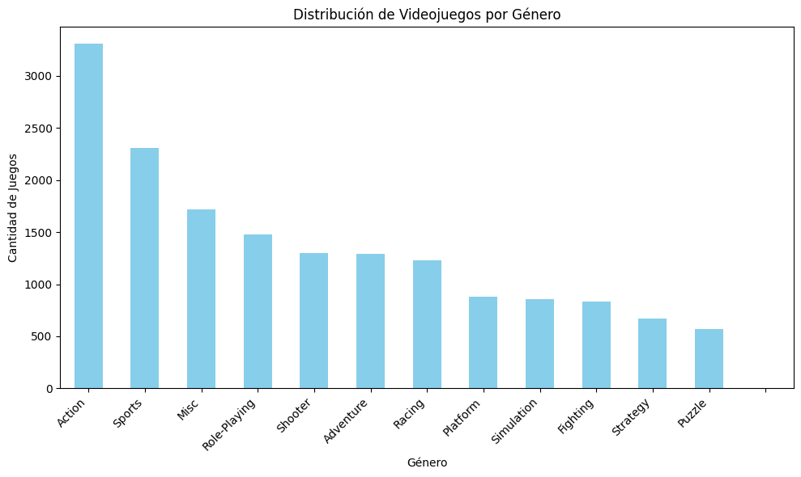

```python
plt.figure(figsize=(10, 6))
distribucion_por_genero.plot(kind='bar', color='skyblue')
plt.title('Distribución de Videojuegos por Género')
plt.xlabel('Género')
plt.ylabel('Cantidad de Juegos')
plt.xticks(rotation=45, ha='right')
plt.tight_layout()

plt.show()
```

Los géneros de Acción y Deportes son los más populares, mientras que otros géneros tienen una representación más limitada

### Perfil de usuario para cada region

```python
ventas_por_plataforma_na = games.groupby('platform')['na_sales'].sum().sort_values(ascending=False)

top_5_plataformas_na = ventas_por_plataforma_na.head(5)

print(top_5_plataformas_na)
```

```
platform
X360    595.74
PS2     572.92
Wii     486.87
PS3     390.13
DS      380.31
Name: na_sales, dtype: float64
```

```python
ventas_por_plataforma_jp = games.groupby('platform')['jp_sales'].sum().sort_values(ascending=False)

top_5_plataformas_jp = ventas_por_plataforma_jp.head(5)

print(top_5_plataformas_jp)
```

```
platform
DS      175.02
PS      139.78
PS2     137.54
SNES    116.55
3DS     100.62
Name: jp_sales, dtype: float64
```

```python
ventas_por_plataforma_eu = games.groupby('platform')['eu_sales'].sum().sort_values(ascending=False)

top_5_plataformas_eu = ventas_por_plataforma_eu.head(5)

print(top_5_plataformas_eu)
```

```
platform
PS2     332.63
PS3     327.21
X360    268.32
Wii     258.32
PS      212.39
Name: eu_sales, dtype: float64
```

Las variaciones en las cuotas de mercado de las plataformas de videojuegos entre las diferentes regiones reflejan una combinación de factores culturales, económicos y de marketing. Comprender estos patrones puede ser útil para las empresas de videojuegos a la hora de desarrollar estrategias de lanzamiento y marketing.

```python
generos_na = games.groupby('genre')['na_sales'].sum().sort_values(ascending=False)

top_5_generos_na = generos_na.head(5)

print(top_5_generos_na)
```

```
genre
Action      863.17
Sports      671.20
Shooter     584.83
Platform    444.44
Misc        399.57
Name: na_sales, dtype: float64
```

```python
generos_jp = games.groupby('genre')['jp_sales'].sum().sort_values(ascending=False)

top_5_generos_jp = generos_jp.head(5)

print(top_5_generos_jp)
```

```
genre
Role-Playing    353.39
Action          160.14
Sports          134.93
Platform        130.71
Misc            107.02
Name: jp_sales, dtype: float64
```

```python
generos_eu = games.groupby('genre')['eu_sales'].sum().sort_values(ascending=False)

top_5_generos_eu = generos_eu.head(5)

print(top_5_generos_eu)
```

```
genre
Action     510.99
Sports     371.33
Shooter    314.52
Racing     234.49
Misc       210.60
Name: eu_sales, dtype: float64
```

```python
na_ventas_rating = games.groupby('rating')['na_sales'].sum().sort_values(ascending=False)

total_na_ventas = games['na_sales'].sum()

pct_na_ventas_rating = (na_ventas_rating / total_na_ventas) * 100

print("Ventas Totales de NA por Clasificación ESRB:")
print(na_ventas_rating)

print("\nPorcentaje de Ventas Totales de NA para Cada Clasificación ESRB:")
print(pct_na_ventas_rating.round(1))
```

```
Ventas Totales de NA por Clasificación ESRB:
rating
E       1274.24
        1227.62
T        747.60
M        742.89
E10+     345.50
K-A        2.56
EC         1.53
AO         1.26
RP         0.00
Name: na_sales, dtype: float64

Porcentaje de Ventas Totales de NA para Cada Clasificación ESRB:
rating
E       29.3
        28.3
T       17.2
M       17.1
E10+     8.0
K-A      0.1
EC       0.0
AO       0.0
RP       0.0
Name: na_sales, dtype: float64
```

```python
jp_ventas_rating = games.groupby('rating')['jp_sales'].sum().sort_values(ascending=False)

total_jp_ventas = games['jp_sales'].sum()

pct_jp_ventas_rating = (jp_ventas_rating / total_jp_ventas) * 100

print("Ventas Totales de JP por Clasificación ESRB:")
print(jp_ventas_rating)

print("\nPorcentaje de Ventas Totales de JP para Cada Clasificación ESRB:")
print(pct_jp_ventas_rating.round(1))
```

```
Ventas Totales de JP por Clasificación ESRB:
rating
        836.77
E       197.96
T       150.70
M        63.58
E10+     40.20
K-A       1.46
AO        0.00
EC        0.00
RP        0.00
Name: jp_sales, dtype: float64

Porcentaje de Ventas Totales de JP para Cada Clasificación ESRB:
rating
        64.8
E       15.3
T       11.7
M        4.9
E10+     3.1
K-A      0.1
AO       0.0
EC       0.0
RP       0.0
Name: jp_sales, dtype: float64
```

```python
eu_ventas_rating = games.groupby('rating')['eu_sales'].sum().sort_values(ascending=False)

total_eu_ventas = games['eu_sales'].sum()

pct_eu_ventas_rating = (eu_ventas_rating / total_eu_ventas) * 100

print("Ventas Totales de EU por Clasificación ESRB:")
print(eu_ventas_rating)

print("\nPorcentaje de Ventas Totales de EU para Cada Clasificación ESRB:")
print(pct_eu_ventas_rating.round(1))
```

```
Ventas Totales de EU por Clasificación ESRB:
rating
E       703.87
        610.18
M       480.00
T       421.79
E10+    183.35
AO        0.61
K-A       0.27
EC        0.11
RP        0.03
Name: eu_sales, dtype: float64

Porcentaje de Ventas Totales de EU para Cada Clasificación ESRB:
rating
E       29.3
        25.4
M       20.0
T       17.6
E10+     7.6
AO       0.0
K-A      0.0
EC       0.0
RP       0.0
Name: eu_sales, dtype: float64
```

Las clasificaciones ESRB desempeñan un papel importante en la industria de los videojuegos, influyendo en las decisiones de compra de los consumidores y, por lo tanto, en las ventas de los juegos.Las clasificaciones ESRB pueden limitar las opciones de marketing y publicidad para los juegos. Los juegos con clasificaciones más altas pueden tener restricciones en ciertos canales de publicidad, lo que puede afectar su alcance.

Como podemos observar en nuestros datos en Norte America hay mejores ventas a pesar de las clasificacion, pero en Japon, se evidencia como en clasificaciones altas como "Mature" posee muy pocas ventas.

### Prueba de hipotesis

Hipotesis Nula (H0): Las calificaciones promedio de los usuarios para las plataformas Xbox One y PC son iguales.

Hipotesis Alternativa (H1):Las calificaciones promedio de los usuarios para las plataformas Xbox One y PC no son las mismas.

```python
alpha = 0.05

xbox = games[games['platform'] == 'XOne']
pc = games[games['platform'] == 'PC']

promedio_xbox = 4.8
promedio_pc = 5.6

results = sts.ttest_ind(xbox["user_score"], pc["user_score"])

print('valor p:',results.pvalue)

if results.pvalue < alpha :
    print("Rechazamos la hipótesis nula")
else:
    print("No podemos rechazar la hipótesis nula")
```

```
valor p: 0.0007068097266608117
Rechazamos la hipótesis nula
```

```python
xbox = games[games['platform'] == 'XOne']


promedio_user_score_xbox_one = xbox['user_score'].mean()

print(promedio_user_score_xbox_one)
```

```
4.805263157894737
```

```python
pc = games[games['platform'] == 'PC']


promedio_user_score_pc = pc['user_score'].mean()

print(promedio_user_score_pc)
```

```
5.5745036572622775
```

El resultado indica que se rechaza la hipótesis nula. Esto significa que existe una diferencia estadísticamente significativa entre las calificaciones promedio de los usuarios de Xbox One y PC. Específicamente, las calificaciones promedio de PC son significativamente más altas que las de Xbox One.

Se uso para probar esta hipotesis una prueba t para comparar las medias de dos grupos

```python
accion= games[games['genre'] == 'Action']
sport = games[games['genre'] == 'Sports']

results = sts.ttest_ind(accion['user_score'], sport['user_score'])


print('valor p:',results.pvalue)

if results.pvalue < alpha :
    print("Rechazamos la hipótesis nula")
else:
    print("No podemos rechazar la hipótesis nula")
```

```
valor p: 7.492568776804778e-09
Rechazamos la hipótesis nula
```

```python
accion = games[games['genre'] == 'Action']


promedio_user_score_accion = accion['user_score'].mean()

print(promedio_user_score_accion)
```

```
3.833202298155427
```

```python
sport = games[games['genre'] == 'Sports']


promedio_user_score_sport = sport['user_score'].mean()

print(promedio_user_score_sport)
```

```
3.2586730268863833
```

Se uso para probar esta hipotesis una prueba t para comparar las medias de dos grupos.

### Conclusion general

Luego del analisis de los datos se puede concluir varias cosas, primero las plataformas como PS2, Xbox 360 y PS3 han dominado el mercado en términos de ventas totales. Sin embargo, se observa una clara evolución con el surgimiento de nuevas consolas como PS4 y Xbox One.

Por otro lado el mercado de videojuegos ha experimentado un crecimiento significativo en las últimas décadas, con picos y valles asociados a lanzamientos importantes y cambios tecnológicos. Asi mismo, los géneros de acción y deportes son los más populares en términos de ventas, aunque la preferencia puede variar según la región.

Existe una cierta correlación entre las puntuaciones de los críticos y las ventas, pero no es una relación perfecta. Otros factores como el marketing y las tendencias de la industria también influyen y por ultimo las preferencias de los jugadores varían significativamente entre las diferentes regiones. Por ejemplo, los juegos de rol son más populares en Japón, mientras que los juegos de acción son más populares en Norteamérica y Europa.